# Forecasting Mental illness trends on twitter

## Using methods discuessed in literature, this model aims to forecast mental illness trends in the Twitter social network

## Setup...

```python
%load_ext autoreload
%autoreload 2
%matplotlib inline
%config InlineBackend.figure_format='retina'
#allows for python 2 syntax to be used
from __future__ import absolute_import, division, print_function
#
import os
os.environ
#
import pandas as pd
import numpy as np
#statistical stuff
import statsmodels.api as sm
import statsmodels.formula.api as smf
import statsmodels.tsa.api as smt

#plotting and visualisation
import matplotlib.pyplot as plt
from matplotlib import style
style.use('ggplot')
import seaborn as sns
#seaborn style
sns.set(style='ticks', context='poster')

#interactive stuff
from pandas.tools.plotting import autocorrelation_plot
from pandas.tools.plotting import scatter_matrix

#from statsmodels.graphics.api import qqplot
pd.set_option('display.float_format',lambda x: '%.5f'% x)
np.set_printoptions(precision=5, suppress=True)
pd.set_option('display.max_columns', 100)
pd.set_option('display.max_rows', 100)

#ADF test
from statsmodels.tsa.stattools import adfuller

#LSTM imports KERAS
from pandas import DataFrame
from pandas import Series
from pandas import concat
from pandas import datetime
from sklearn.metrics import mean_squared_error
from sklearn.preprocessing import MinMaxScaler
from keras.models import Sequential
from keras.layers import Dense
from keras.layers import LSTM
from math import sqrt
from matplotlib import pyplot

from IPython.display import Image
```

## Get the data...

### Snippet from the proposed Mongodb

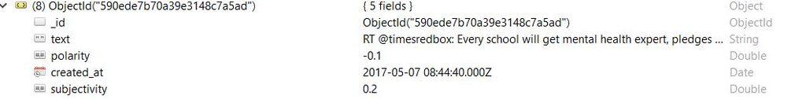

```python
Image(filename='mongo.jpg')
```

#### This data is collected from Twitter using the tweepyAPI. The streamer outputted data into a MongoDB collection and was outputted into a csv file.

## Data Understanding

- Data was collected from twitter, using a Streaming API (Tweepy)

```python
data = pd.read_csv('day_collection_tweets.csv', header =0, parse_dates=['created_at'])
data.head()
```

|  | text | polarity | created_at | subjectivity |
| --- | --- | --- | --- | --- |
| 0 | RT @thegooglefact: Traveling is good for you i... | 0.70000 | 2017-05-07 08:44:39 | 0.60000 |
| 1 | RT @bronwendavies_: Mental health is so much m... | 0.37500 | 2017-05-07 08:44:39 | 0.57500 |
| 2 | RT @catwangty: vous parlez de suicide comme d'... | 0.00000 | 2017-05-07 08:44:39 | 0.00000 |
| 3 | RT @kyle_clyd: @GoodWillsmith maybe I need to ... | 0.40000 | 2017-05-07 08:44:40 | 0.35000 |
| 4 | Cqc complaint psych 'you on any medication' "n... | -0.02500 | 2017-05-07 08:44:40 | 0.60000 |

```python
data.shape
```

```
(331693, 4)
```

```python
neg = data.loc[data['polarity'] < 0 ]
neg.head()
#neg.to_csv('negative_tweets.csv')
```

|  | text | polarity | created_at | subjectivity |
| --- | --- | --- | --- | --- |
| 4 | Cqc complaint psych 'you on any medication' "n... | -0.02500 | 2017-05-07 08:44:40 | 0.60000 |
| 7 | RT @timesredbox: Every school will get mental ... | -0.10000 | 2017-05-07 08:44:40 | 0.20000 |
| 11 | @walkamileuk ...right after attacking the mobi... | -0.10000 | 2017-05-07 08:44:41 | 0.20000 |
| 18 | I'm no expert or anything but I don't think de... | -0.15000 | 2017-05-07 08:44:43 | 0.60000 |
| 19 | RT @TheTopCobber: i get out of school work by ... | -0.15000 | 2017-05-07 08:44:44 | 0.60000 |

```python
pos = data.loc[data['polarity'] > 0 ]
pos.head()
#pos.to_csv('positive_tweets.csv')
```

|  | text | polarity | created_at | subjectivity |
| --- | --- | --- | --- | --- |
| 0 | RT @thegooglefact: Traveling is good for you i... | 0.70000 | 2017-05-07 08:44:39 | 0.60000 |
| 1 | RT @bronwendavies_: Mental health is so much m... | 0.37500 | 2017-05-07 08:44:39 | 0.57500 |
| 3 | RT @kyle_clyd: @GoodWillsmith maybe I need to ... | 0.40000 | 2017-05-07 08:44:40 | 0.35000 |
| 12 | RT @doctor_oxford: A whole 'revolution' with '... | 0.21061 | 2017-05-07 08:44:41 | 0.45152 |
| 14 | RT @LeoraCruddas: No @theresa_may this is *not... | 0.01667 | 2017-05-07 08:44:41 | 0.24444 |

```python
neg.loc[:'2017-05-08 07:00:05']
```

[output not shown]

[output cut: 71 more lines]

79926 rows × 4 columns

# Data Preparation

- Transforming the data so it is useful for time series and looking into the user behaviour
- tweets are collected every second, resampling forces this into a prefered frequency

### Resample the negative tweets into, tweets per 30 minuites

```python
neg['created_at'] = pd.to_datetime(pd.Series(neg['created_at']))

#set index to created_at
neg.set_index('created_at', drop = False, inplace=True)

#neg.index.tz_localize('GMT').tz_convert('EST')

#neg.index = neg.index - DateOffset(hours = 0)

#created_at index is formatted to per min

tweets_pm = neg['created_at'].resample('30t').count()
```

```python
tweets_pm.head()
```

```
created_at
2017-05-07 08:30:00     846
2017-05-07 09:00:00    1547
2017-05-07 09:30:00    2060
2017-05-07 10:00:00    1613
2017-05-07 10:30:00    1381
Freq: 30T, Name: created_at, dtype: int64
```

```python
tweets_pm.tail()
```

```
created_at
2017-05-08 05:30:00    1493
2017-05-08 06:00:00    1523
2017-05-08 06:30:00    1607
2017-05-08 07:00:00    3685
2017-05-08 07:30:00     432
Freq: 30T, Name: created_at, dtype: int64
```

### Visulise the transformed data into a time series chart

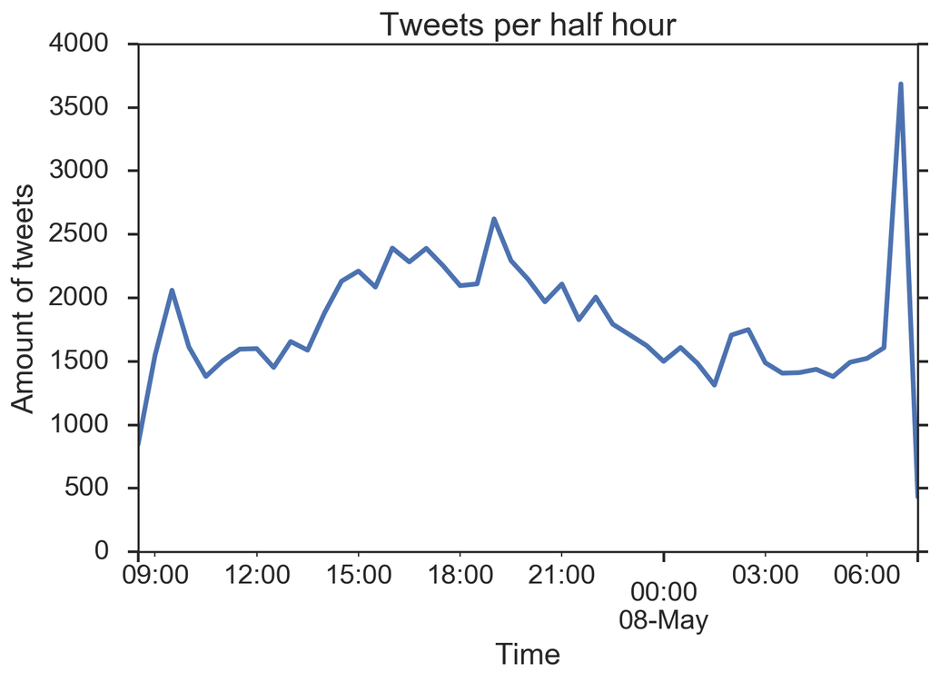

```python
fig, ax = plt.subplots(figsize = (8,6))
tweets_pm.plot(ax=ax)
ax.set_title('Tweets per half hour')
ax.set_ylabel('Amount of tweets')
ax.set_xlabel('Time')
ax.xaxis.set_ticks_position('bottom')
fig.tight_layout()
plt.plot(tweets_pm)
```

## descibe the data

```python
print ('Statistical Description\n',tweets_pm.describe())
print ('First 5 Values\n', tweets_pm.head())
print ('Shape of dataset\n',tweets_pm.shape)
```

```
Statistical Description
 count     47.00000
mean    1787.29787
std      496.73503
min      432.00000
25%     1496.50000
50%     1656.00000
75%     2102.50000
max     3685.00000
Name: created_at, dtype: float64
First 5 Values
 created_at
2017-05-07 08:30:00     846
2017-05-07 09:00:00    1547
2017-05-07 09:30:00    2060
2017-05-07 10:00:00    1613
2017-05-07 10:30:00    1381
Freq: 30T, Name: created_at, dtype: int64
Shape of dataset
 (47,)
```

### Split into Training and Testing (holdout) dataset

- Cannot randomly select training and testing, because that breaks the dependency structure

```python
n_sample = tweets_pm.shape[0]
```

```python
n_train = int(0.80*n_sample)+1
n_forecast=n_sample-n_train
#ts_df
ts_train = tweets_pm.iloc[:n_train][1:]
ts_test = tweets_pm.iloc[n_train:][1:]
print(tweets_pm.shape)
print(tweets_pm.shape)
print("training series:" "\n", ts_train.tail(), "\n")
print("testing series:" "\n", ts_test.head())
```

```
(47,)
(47,)
training series:
 created_at
2017-05-08 01:00:00    1484
2017-05-08 01:30:00    1313
2017-05-08 02:00:00    1707
2017-05-08 02:30:00    1750
2017-05-08 03:00:00    1489
Freq: 30T, Name: created_at, dtype: int64

testing series:
 created_at
2017-05-08 04:00:00    1411
2017-05-08 04:30:00    1437
2017-05-08 05:00:00    1380
2017-05-08 05:30:00    1493
2017-05-08 06:00:00    1523
Freq: 30T, Name: created_at, dtype: int64
```

# Visualise the data based on the first 20 lags

```python
def tsplot(y, lags=None, title='', figsize=(14,8)):
    #examine patterns of the ACF and PACF, aloing with ts and histograms
    #source:
    fig=plt.figure(figsize=figsize)
    layout = (2,2)
    ts_ax = plt.subplot2grid(layout, (0 ,0))
    hist_ax = plt.subplot2grid(layout, (0,1))
    acf_ax = plt.subplot2grid(layout, (1,0))
    pacf_ax = plt.subplot2grid(layout,(1,1))

    y.plot(ax=ts_ax)
    ts_ax.set_title(title)
    y.plot(ax=hist_ax, kind='hist', bins=25)
    hist_ax.set_title('histograms')
    smt.graphics.plot_acf(y, lags=lags, ax=acf_ax)
    smt.graphics.plot_pacf(y, lags=lags, ax=pacf_ax)
    [ax.set_xlim(0) for ax in [acf_ax, pacf_ax]]
    sns.despine()
    fig.tight_layout()
    return ts_ax, acf_ax, pacf_ax
```

- Does not have a strong trend
- with more data perhaps could have seen a cycle

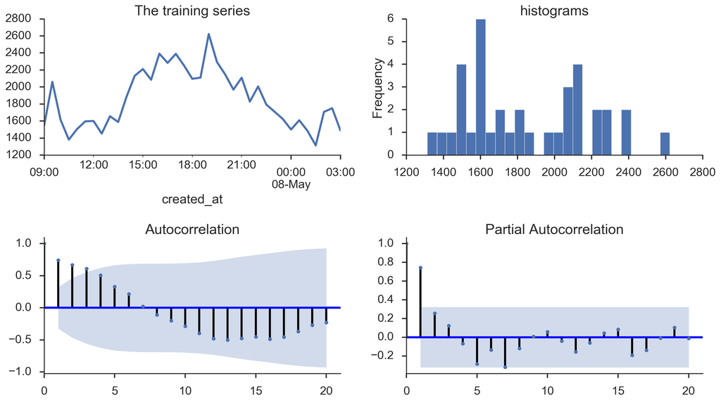

```python
tsplot(ts_train, title = "The training series", lags = 20)
```

- autocorrelation gradually tails off
- partial autocorrelation does not exactly tail off

# Use the dickey fuller test to check sationarity

```python
#i can do pearson corrolation coefitiant vs dickey-fuller
def test_stationarity(timeseries):

    #Determing rolling statistics
    rolmean = pd.rolling_mean(timeseries, window=10)
    rolstd = pd.rolling_std(timeseries, window=10)

    #Plot rolling statistics:
    orig = plt.plot(timeseries, color='blue',label='Original')
    mean = plt.plot(rolmean, color='red', label='Rolling Mean')
    std = plt.plot(rolstd, color='black', label = 'Rolling Std')
    plt.legend(loc='best')
    plt.title('Rolling Mean & Standard Deviation')
    plt.show(block=False)

    #Perform Dickey-Fuller test:
    print ('Results of Dickey-Fuller Test:')
    dftest = adfuller(timeseries, autolag='AIC')
    dfoutput = pd.Series(dftest[0:4], index=['Test Statistic','p-value','#Lags Used','Number of Observations Used'])
    for key,value in dftest[4].items():
        dfoutput['Critical Value (%s)'%key] = value
    print (dfoutput)
```

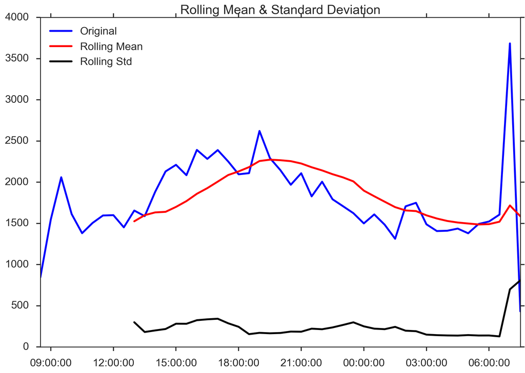

```
Results of Dickey-Fuller Test:
Test Statistic                -2.70721
p-value                        0.07280
#Lags Used                     1.00000
Number of Observations Used   45.00000
Critical Value (1%)           -3.58483
Critical Value (10%)          -2.60234
Critical Value (5%)           -2.92830
dtype: float64
```

```python
test_stationarity(tweets_pm)
```

# Take the logged returns to make the data stationary

```python
log_return_data = pd.DataFrame()

log_return_data['count_log_return'] = np.log(tweets_pm[1:]/ tweets_pm[1:].shift())

log_return_data.describe()
```

|  | count_log_return |
| --- | --- |
| count | 45.00000 |
| mean | -0.02835 |
| std | 0.36323 |
| min | -2.14360 |
| 25% | nan |
| 50% | nan |
| 75% | nan |
| max | 0.82990 |

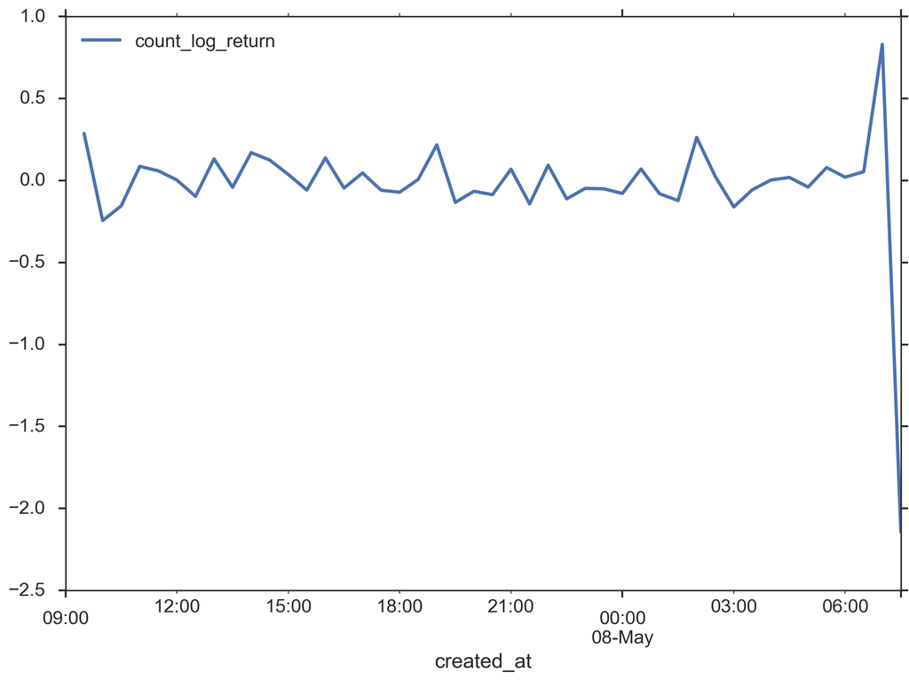

```python
log_return_data.plot()
```

- Twitter data is noisy.
- Unpredictible

[figure not shown]

```python
fig = plt.figure()
fig.set_figwidth(20)
fig.set_figheight(15)

_ = autocorrelation_plot(log_return_data, label='autocorrolation')

_ = plt.legend(loc= 'upper right')
```

The data looks stationary with a mean of approximatly 0

## Look into ARIMA statistics to estimate model performance

- Specified the AR4 model
- Akaike information criterion (AIC)
- Bayesian information criterion (BIC)
- Both are measures of the in sample fit of the data
- functions of estimations of underlying standard error of residual
- Bottom statistics satisfies the assumpsions of model.
- residuals should look similar to a white noise

```python
arima100 = sm.tsa.SARIMAX(ts_train, order=(4,1,1))
model_results = arima100.fit()
model_results.summary()
```

Statespace Model Results

| Dep. Variable: | created_at | No. Observations: | 37 |
| --- | --- | --- | --- |
| Model: | SARIMAX(4, 1, 1) | Log Likelihood | -242.849 |
| Date: | Tue, 16 May 2017 | AIC | 497.698 |
| Time: | 23:18:23 | BIC | 507.364 |
| Sample: | 05-07-2017 | HQIC | 501.106 |
|  | - 05-08-2017 |  |  |
| Covariance Type: | opg |  |  |

|  | coef | std err | z | P>\|z\| | [0.025 | 0.975] |
| --- | --- | --- | --- | --- | --- | --- |
| ar.L1 | 0.0100 | 0.691 | 0.014 | 0.988 | -1.345 | 1.365 |
| ar.L2 | -0.1488 | 0.310 | -0.480 | 0.631 | -0.757 | 0.459 |
| ar.L3 | 0.0402 | 0.320 | 0.126 | 0.900 | -0.587 | 0.667 |
| ar.L4 | 0.3128 | 0.206 | 1.515 | 0.130 | -0.092 | 0.718 |
| ma.L1 | -0.3341 | 0.752 | -0.444 | 0.657 | -1.809 | 1.140 |
| sigma2 | 4.158e+04 | 1.21e+04 | 3.442 | 0.001 | 1.79e+04 | 6.53e+04 |

| Ljung-Box (Q): | 31.57 | Jarque-Bera (JB): | 3.61 |
| --- | --- | --- | --- |
| Prob(Q): | 0.63 | Prob(JB): | 0.16 |
| Heteroskedasticity (H): | 0.56 | Skew: | 0.75 |
| Prob(H) (two-sided): | 0.33 | Kurtosis: | 2.58 |

### Perform a grid search to find optimal values for p,d,q

```python
import itertools

p_min=0
d_min=0
q_min=0
p_max=4
d_max=0
q_max=4

results_bic = pd.DataFrame(index=['AR{}'.format(i) for i in range(p_min, p_max+1)],
                          columns=['MA{}.'.format(i) for i in range(q_min,q_max+1)])
for p,d,q in itertools.product(range(p_min,p_max+1),
                              range(d_min,d_max+1),
                              range(q_min,q_max+1)):
    if p==0 and d==0 and q==0:
        results_bic.loc['AR{}'.format(p), 'MA{}'.format(q)] = np.nan
        continue
    try:
        model = sm.tsa.SARIMAX(ts_train, order=(p,d,q),
                              #enforce_stationary = False
                               #enforce_invertability =False
                              )
        results = model.fit()
        results_bic.loc['AR{}'.format(p), 'MA{}'.format(q)] = results.bic
    except:
        continue
results_bic = results_bic[results_bic.columns].astype(float)
```

```python
results_bic
```

|  | MA0. | MA1. | MA2. | MA3. | MA4. | MA0 | MA2 | MA3 | MA1 | MA4 |
| --- | --- | --- | --- | --- | --- | --- | --- | --- | --- | --- |
| AR0 | nan | nan | nan | nan | nan | nan | nan | nan | nan | nan |
| AR1 | nan | nan | nan | nan | nan | 517.29085 | 520.70949 | 523.03665 | 517.12601 | 524.31415 |
| AR2 | nan | nan | nan | nan | nan | 518.15038 | nan | nan | nan | 528.73749 |
| AR3 | nan | nan | nan | nan | nan | 520.24728 | nan | nan | 523.78077 | nan |
| AR4 | nan | nan | nan | nan | nan | 523.57932 | nan | nan | 525.23213 | nan |

- some functions automatiaclly choose 'best' model.
- good to see the numbers, could choose lowest AIC or BIC
- However, this is for in sample data. Problem is to forecast.

```python
# alternitive model selection method, limited to only searching AR and MA params
train_results = sm.tsa.arma_order_select_ic(ts_train, ic=['aic', 'bic'], trend = 'nc')
print('AIC', train_results.aic_min_order)
print('BIC', train_results.bic_min_order)
```

```
AIC (1, 1)
BIC (1, 1)
```

## Model Diagnostic checking

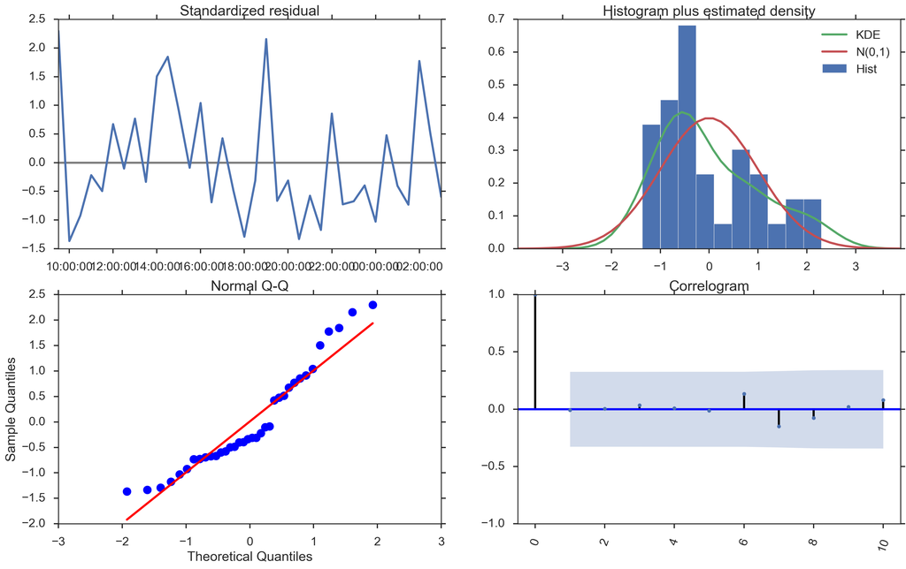

```python
model_results.plot_diagnostics(figsize=(20,12))
plt.xticks(rotation=70)
```